# Exploratory Data Analysis

Author

Affiliation

Bruna Moreno, Daniele Bononi, João Vitor Calvo, Renan Fantine

Department of Genetics, ESALQ-USP

# Introduction

This report presents a comprehensive exploratory data analysis of a soybean breeding program in **Zambia**, exploring **four trials** and **five key soybean traits**. The main objectives are to assess variation, detect unusual values, compute measures of central tendency and dispersion, and investigate relationships between traits. First, we describe the custom functions developed to perform the EDA. In the following section, we present our insights regarding the experimental database. Finally, we analyze the performance of a trait to support genotype selection across the evaluated trials.

# Data characterization

The dataset is composed of phenotypic records from a soybean breeding program conducted in Zambia during the 2023 growing season. A total of 29 genotypes were evaluated across four distinct locations (L0118, L0133, L074, and L0134), representing different environmental conditions. Each genotype was replicated three times per location, except for “G321”, which had six replicates in each trial.

Five agronomic traits were selected based on data availability and breeding importance: Days to Flowering (FLW_DAYS), Grain Yield (GY), Plant Height at R8 stage (PH_R8), Emergence Count (PL_EMERG_COUNT), and Pod Shattering.

```r
# Loading packages
library(ggplot2)
library(patchwork)
library(tidyr)
library(dplyr)
library(purrr)
library(knitr)
library(kableExtra)
library(grid)
library(ggcorrplot)

# Loading data (Zambia)
data = read.csv("https://raw.githubusercontent.com/mauricioaraujj/Pan_African_Trials_Network/refs/heads/main/data/data.csv", sep = ';') |> filter(COUNTRY == "Zambia")

# Selecting traits
traits <- c("FLW_DAYS", "GY", "PH_R8", "PL_EMERG_COUNT", "Pod_Shattering")
selected_data <- data |>
  select(COUNTRY, YEAR, env, gen, loc, SEASON, rep, check, all_of(traits)) |>
  filter(loc %in% c("L0118", "L0133", "L074", "L0134") & YEAR == "2023") |>
  mutate(trial = case_when(
    loc == "L0118" & YEAR == "2023" ~ 1,
    loc == "L0133" & YEAR == "2023" ~ 2,
    loc == "L074"  & YEAR == "2023" ~ 3,
    loc == "L0134" & YEAR == "2023" ~ 4)) |>
  mutate(trial = as.factor(trial))

# Trial 1 - Local "L0118" / Year "2023"
trial_1 <- selected_data |> filter(trial == "1")
genotypes_1 <- trial_1$gen

# Trial 2 - Local "L0133" / Year "2023"
trial_2 <- selected_data |> filter(trial == "2")
genotypes_2 <- trial_2$gen

# Trial 3 - Local "L074" / Year "2023"
trial_3 <- selected_data |> filter(trial == "3")
genotypes_3 <- trial_3$gen

# Trial 4 - Local "L0134" / Year "2023"
trial_4 <- selected_data |> filter(trial == "4")
genotypes_4 <- trial_4$gen
```

# Used Functions

```r
# Function 1 - Single Trial Summary
trial_summary <- function(df, title, traits, bins){

  # Dataframe long
  df_long <- df |>
    pivot_longer(cols = all_of(traits),
      names_to = "Variable",
      values_to = "value")

  # Measures of Position and Dispersion - Quantitative Variable
  stats_df <- df_long |>
    group_by(Variable) |>
    summarise(
      mean = mean(value, na.rm = TRUE),
      median = median(value, na.rm = TRUE),
      variance = var(value, na.rm = TRUE),
      sd = sd(value, na.rm = TRUE),
      cv = (sd/mean),
      min = min(value, na.rm = TRUE),
      max = max(value, na.rm = TRUE),
      range = max(value, na.rm = TRUE) - min(value, na.rm = TRUE)) |>
    mutate(across(where(is.numeric), ~round(.x, 3)))

  # Correlation between traits
  cor_mat <- df |>
    select(all_of(traits)) |>
    cor(use = "complete.obs")

  p1 <-ggcorrplot(cor_mat,
           hc.order = TRUE,
           type = "upper",
           lab = TRUE,
           lab_size = 3,
           colors = c("red", "white", "blue"),
           title = title)

  # Traits Boxplots
  p2 <- ggplot(df_long, aes(x = value, y = Variable, fill = Variable)) +
        geom_boxplot(alpha = 0.7) +
        facet_wrap(~Variable, scales = "free") +
        geom_point(data = stats_df, aes(x = mean, y = Variable),
          shape = 17, color = "#10342d", size = 2) +
        scale_fill_brewer(palette = "Set2") +
        labs(title = title,
          x = "Values",
          y = "",
          fill = "Trait") +
        theme_minimal() +
        theme(axis.text.y = element_blank(),text = element_text(size = 18))

  # Traits Density Plot
  p3 <- ggplot(df_long, aes(x = value, fill = Variable)) +
        geom_density(alpha = 0.6, show.legend = FALSE) +
        geom_vline(data = stats_df, aes(xintercept = mean),
          linetype = "dashed", linewidth = 0.8, show.legend = FALSE) +
        geom_text(data = stats_df,aes(x = mean, y = Inf, label = round(mean, 2)),
          vjust = 1.5,hjust = -0.4 ,size = 3.5, color = "black") +
        facet_wrap(~Variable, scales = "free") +
        scale_fill_brewer(palette = "Set2") +
        labs(
          title = paste(title),
          x = "Value",
          y = "Density") +
        theme_minimal() +
        theme(text = element_text(size = 18))

  # Traits Histogram
  p4 <- ggplot(df_long, aes(x = value, fill = Variable)) +
        geom_histogram(bins = 30, color = "white",
          alpha = 0.7, show.legend = FALSE) +
        facet_wrap(~Variable, scales = "free") +
        scale_fill_brewer(palette = "Set2") +
        labs(title = title,
          x = "Value",
          y = "Count") +
        theme_minimal() +
        theme(text = element_text(size = 18))

  return(list(stats = stats_df,correlation = p1,boxplot = p2, density = p3, histogram = p4))
}


# Function 2 - Single Trial Pairwise Scatter plot
pairwise_scatter <- function(df, title, trait1, trait2, t1_lab, t2_lab){

  # Dataframe long
  df_long <- df |>
    pivot_longer(cols = all_of(c(trait1, trait2)),
      names_to = "variable",
      values_to = "value") |>
    mutate(Variable = variable)

  # Trait1 and Trait2 - Scatter plot
  p1 <- ggplot(df, aes(x = .data[[trait1]], y = .data[[trait2]])) +
        geom_point(color = "olivedrab4", alpha = 0.7) +
        labs(
          title = paste(title),
          x = t1_lab,
          y = t2_lab,
          caption = paste("Correlation: ",
          round(cor(df[[trait1]], df[[trait2]], use = "complete.obs"), 2))) +
        theme_minimal() +
        theme(text = element_text(size = 18))

  return (scatter = p1)
}

# Function 3 - Single Trial Boxplot by Genotype
boxplot_by_genotype <- function(df, title, trait, trait_lab){

  # Dataframe long
  df_long <- df |>
    pivot_longer(cols = all_of(trait),
      names_to = "Variable",
      values_to = "value")
  stats_df <- df_long |>
    group_by(gen) |>
    summarise(mean = mean(value, na.rm = TRUE), .groups = "drop")
  df_plot <- df_long |>
    left_join(stats_df, by = "gen")

  p1 <- ggplot(df_plot, aes(x = as.factor(gen), y = value, fill = mean)) +
        geom_boxplot(alpha = 0.7) +
        geom_jitter(width = .2, size = 2, alpha = .75, color = "black") +
        scale_fill_viridis_c() +
        labs(title = title,
          x = "Genotypes",
          y = trait_lab,
          fill = "Mean") +
        theme_minimal() +
        theme(axis.text.y = element_text(size = 10)) +
        theme(axis.text.x = element_text(size = 8))

  return (boxplot_genotypes = p1)
}

# Function 4 - Single Trials Analysis Together
single_trials_together <- function(df, title, traits) {

  # Dataframe long
  df_long <- df |>
    mutate(Trial = as.factor(trial)) |>
    pivot_longer(
      cols = all_of(traits),
      names_to = "Trait",
      values_to = "Value") |>
    filter(!is.na(Value))

  # Boxplots
  p1 <- ggplot(df_long, aes(x = Trial, y = Value, fill = Trial)) +
          geom_boxplot(outlier.colour = "black", outlier.size = 0.5) +
          facet_wrap(~Trait, scales = "free") +
          theme_minimal() +
          labs(title = title)

  # Density Plot
  p2 <- ggplot(df_long, aes(x = Value, fill = Trial, group = Trial)) +
          geom_density(alpha = 0.4) +
          facet_wrap(~Trait, scales = "free") +
          theme_light() +
          labs(title = title)

return (list(boxplots = p1, density = p2))
}

# Function 5 - All Trials Boxplot By Genotype
boxplot_genotype_all_in_one <- function(df, trait) {

  # Boxplot by Genotype and Trial
  p1 <- ggplot(df, aes(x = reorder(gen, !!sym(trait)), y = !!sym(trait), fill = trial)) +
        geom_boxplot(alpha = 0.7, outlier.shape = NA, na.rm = TRUE) +
        labs(
          title = paste("All Trials Boxplot:", trait),
          x = "Genotypes",
          y = trait,
          fill = "Trial"
        ) +
        theme_minimal() +
        theme(
          axis.text.x = element_text(angle = 90, vjust = 0.5, hjust = 1, size = 8),
          legend.position = "top",
          panel.grid.minor = element_blank())

  # Boxplot by Genotype
  p2 <- ggplot(df, aes(x = reorder(gen, !!sym(trait)), y = !!sym(trait))) +
        geom_boxplot(fill = "grey80", color = "black", outlier.shape = NA,na.rm = TRUE) +
        geom_jitter(aes(color = trial),width = 0.2,size = 1.2,alpha = 0.8, na.rm = TRUE) +
        labs(
          title = paste("All Trials Boxplot:", trait),
          x = "Genotypes",
          y = trait,
          color = "Trial") +
        theme_minimal() +
        theme(
          axis.text.x = element_text(angle = 90, vjust = 0.5, hjust = 1, size = 8),
          legend.position = "top",
          panel.grid.minor = element_blank())

  return (list(boxplot_gt_trial = p1, boxplot_gt = p2))
}


# Function 6 - Across Trials Correlation
across_trials_correlation <- function(df, title, traits) {

  # Correlation Plot with all trials
  cor_total <- df |>
    select(all_of(traits)) |>
    cor(use = "pairwise.complete.obs")

  p1 <-ggcorrplot(cor_total,
         hc.order = TRUE,
         type = "upper",
         lab = TRUE,
         lab_size = 3,
         colors = c("red", "white", "blue"),
         title = title)

  return(all_cor = p1)
}
```

# Trials Overview

First, some basic statistics were computed for each trial, to facilitate comparison and evaluation of traits:

Table 1: Measures of central tendency and dispersion of trials conducted in Zambia

|  | FLW_DAYS T1 | FLW_DAYS T2 | FLW_DAYS T3 | FLW_DAYS T4 | GY T1 | GY T2 | GY T3 | GY T4 | PH_R8 T1 | PH_R8 T2 | PH_R8 T3 | PH_R8 T4 | PL_EMERG_COUNT T1 | PL_EMERG_COUNT T2 | PL_EMERG_COUNT T3 | PL_EMERG_COUNT T4 | Pod_Shattering T1 | Pod_Shattering T2 | Pod_Shattering T3 | Pod_Shattering T4 |
| --- | --- | --- | --- | --- | --- | --- | --- | --- | --- | --- | --- | --- | --- | --- | --- | --- | --- | --- | --- | --- |
| Mean | 50.34 | 56.74 | 46.33 | 44.27 | 1402.99 | 3676.50 | 3219.40 | 4755.74 | 51.34 | 86.16 | 78.68 | 86.95 | 164.60 | 86.89 | 175.19 | 163.51 | 2.27 | 1.08 | 1.08 | 1.01 |
| Median | 50.00 | 55.50 | 47.00 | 43.00 | 1450.85 | 3712.64 | 3347.13 | 4723.68 | 48.50 | 85.50 | 79.67 | 88.17 | 150.00 | 75.00 | 168.00 | 159.00 | 2.00 | 1.00 | 1.00 | 1.00 |
| Variance | 11.96 | 31.83 | 52.45 | 9.30 | 204233.23 | 953404.19 | 777245.79 | 1118238.33 | 857.37 | 268.17 | 171.14 | 145.31 | 3541.10 | 2512.73 | 3021.21 | 2505.40 | 0.74 | 0.10 | 0.10 | 0.01 |
| Sd | 3.46 | 5.64 | 7.24 | 3.05 | 451.92 | 976.42 | 881.62 | 1057.47 | 29.28 | 16.38 | 13.08 | 12.05 | 59.51 | 50.13 | 54.97 | 50.05 | 0.86 | 0.31 | 0.31 | 0.10 |
| Cv | 0.07 | 0.10 | 0.16 | 0.07 | 0.32 | 0.27 | 0.27 | 0.22 | 0.57 | 0.19 | 0.17 | 0.14 | 0.36 | 0.58 | 0.31 | 0.31 | 0.38 | 0.29 | 0.29 | 0.10 |
| Min | 44.00 | 29.00 | 0.00 | 40.00 | 286.60 | 1421.03 | 1267.59 | 2326.44 | 25.33 | 46.00 | 0.00 | 50.00 | 66.00 | 9.00 | 0.00 | 77.00 | 1.00 | 1.00 | 0.00 | 1.00 |
| Max | 57.00 | 80.00 | 51.00 | 49.00 | 2422.48 | 5684.14 | 5053.79 | 7498.85 | 308.33 | 130.00 | 102.67 | 109.00 | 300.00 | 219.00 | 300.00 | 300.00 | 4.00 | 3.00 | 2.00 | 2.00 |
| Range | 13.00 | 51.00 | 51.00 | 9.00 | 2135.88 | 4263.11 | 3786.20 | 5172.41 | 283.00 | 84.00 | 102.67 | 59.00 | 234.00 | 210.00 | 300.00 | 223.00 | 3.00 | 2.00 | 2.00 | 1.00 |

An outlier was identified for plant height (PH_R8) ( Table 1). This data point was excluded due to its biological anomalousness. It is highly unlikely for a soybean plant to reach 308.33 cm, especially when the trial mean was only 51.34 cm. This inconsistency likely originates from a manual recording error.

```r
# Removing outliers
trial_1 <- trial_1 |>
  mutate(PH_R8 = ifelse(PH_R8 > 200, NA, PH_R8))
trial_3 <- trial_3 |>
  mutate(across(all_of(traits),~ if_else(gen == "G216" & env == "E0282", NA_real_ ,.))) |>
  mutate(FLW_DAYS = ifelse(FLW_DAYS == 0, NA, FLW_DAYS))

selected_data <- selected_data |>
  mutate(PH_R8 = ifelse(PH_R8 > 200, NA, PH_R8)) |>
  mutate(across(all_of(traits),~ if_else(gen == "G216" & env == "E0282", NA_real_ ,.))) |>
  mutate(FLW_DAYS = ifelse(FLW_DAYS == 0, NA, FLW_DAYS))

# Function 1 - Single Trials Summary
all_trials_summary <- list()
trials <- list(trial_1, trial_2, trial_3, trial_4)
for(i in seq_along(trials)){
  title <- paste("Trial", i)
  all_trials_summary[[i]] <- trial_summary(trials[[i]],title, traits, 50)
}
```

Now, some plots analysing all the traits within each trial:

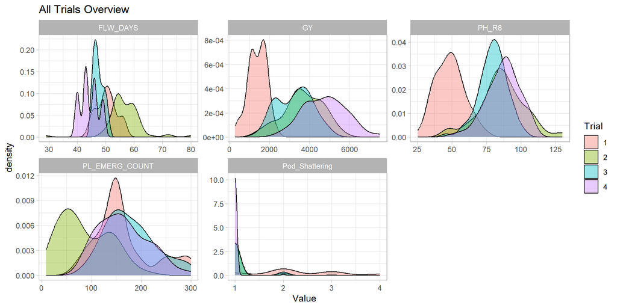

Figure 1: Density plot of traits within each trial

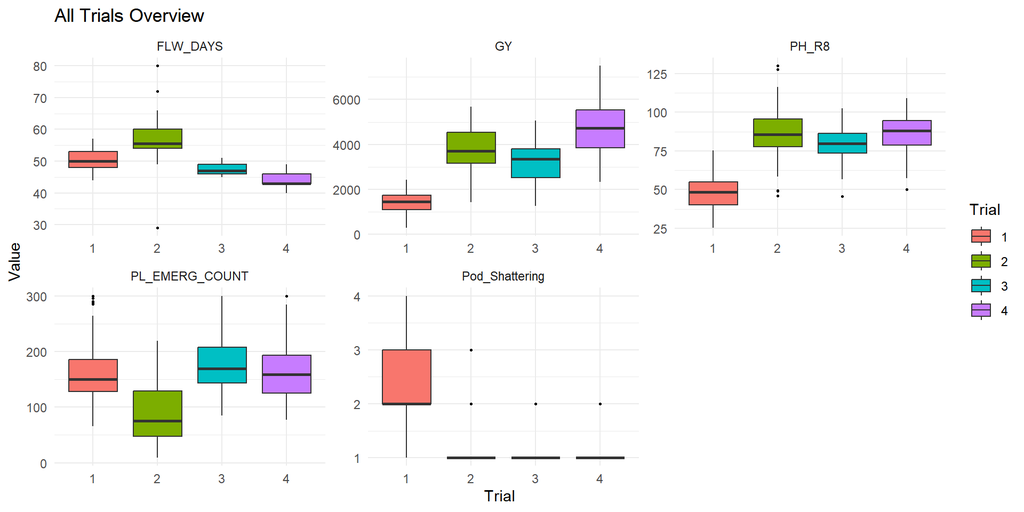

Figure 2: Boxplot of traits within each trial

Regarding the boxplot analyses performed by trait, comparing genotypes and environments, clear trends can be observed. For the Grain Yield (GY) trait, mean values are consistently higher across almost all genotypes in environment L0134 ( Figure 2). This location stands out as a high-potential environment, likely providing optimal edaphoclimatic conditions that allowed the germplasm to express its maximum genetic potential.

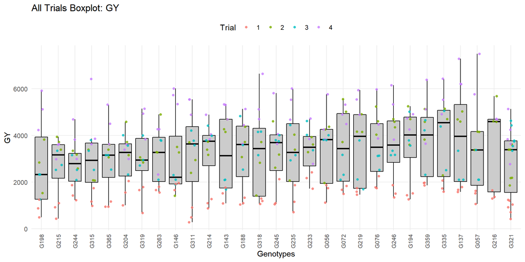

Figure 3: Genotypes Boxplot - Grain Yield

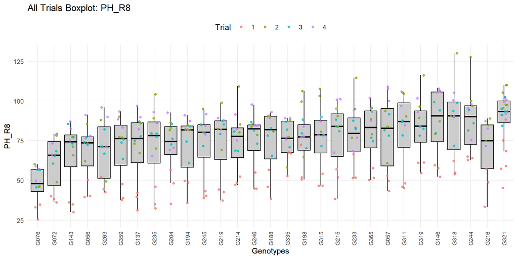

Figure 4: Genotypes Boxplot - Plant Height

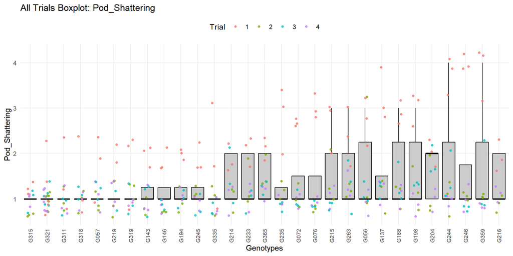

Figure 5: Genotypes Boxplot - Pod Shattering

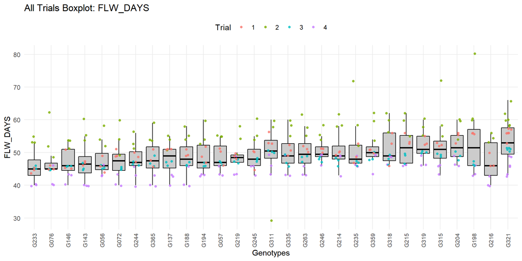

Figure 6: Genotypes Boxplot - Days to Flowering

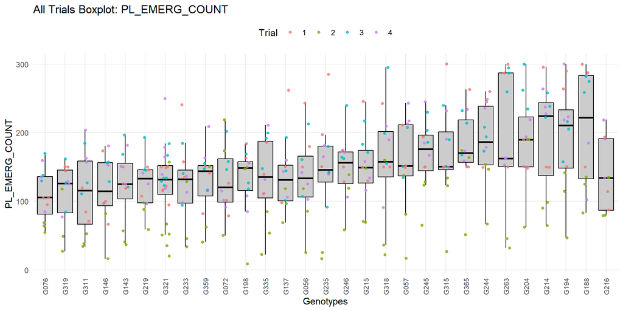

Figure 7: Genotypes Boxplot - Plant Emergence

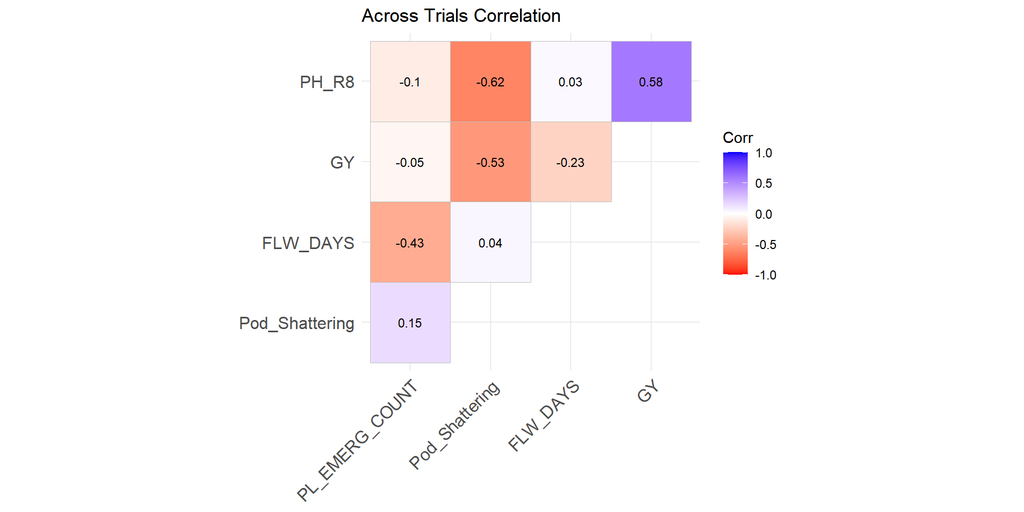

Figure 8: Traits Correlation Across Trials

# Trial 1 - Local “L0118” / Year “2023”

Trait correlations on trial 1 were generally low ( Figure 9). Pod shattering exhibited a weak positive correlation with grain yield (GY) (0.26), as did plant height at maturity (PH_R8) with days to flowering (FLW_DAYS) (0.25). A significant finding was the negative correlation between FLW_DAYS and GY (-0.45), indicating that early-maturing genotypes are more likely to achieve higher yields in this environment.

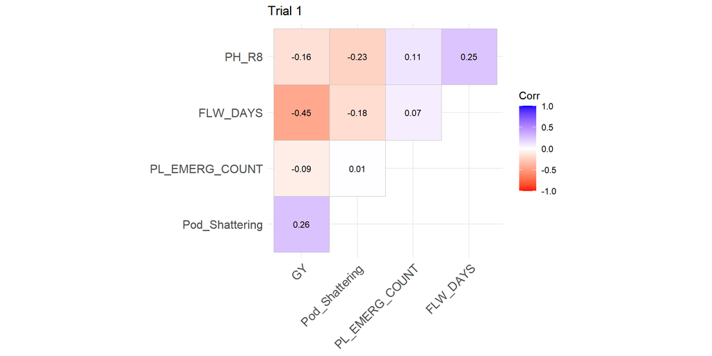

Figure 9: Trial 1 - Traits Correlation

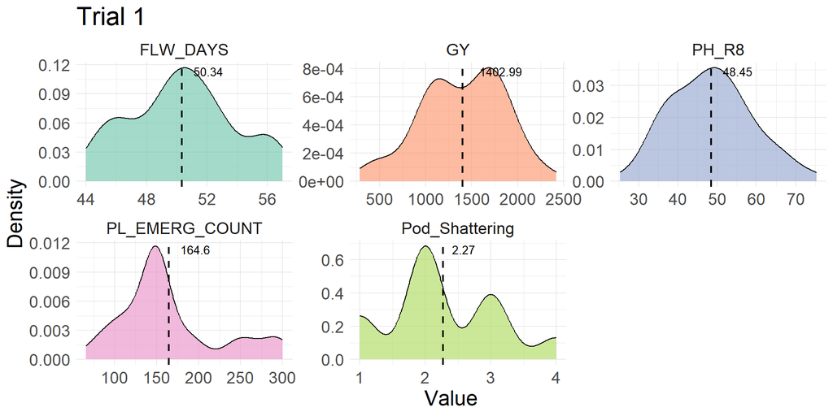

Figure 10: Trial 1 - Traits Density Plot

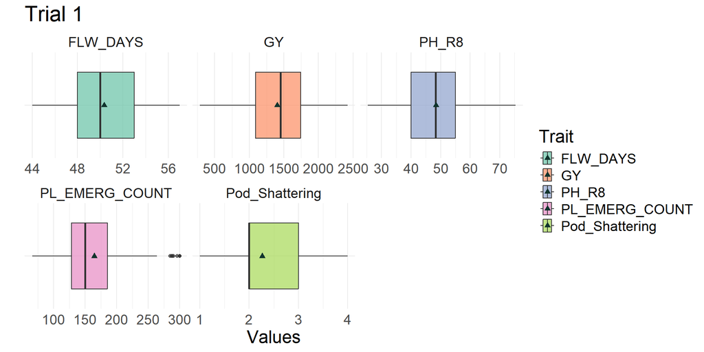

Figure 11: Trial 1 - Traits Boxplot

[figure not shown]

Figure 12: Trial 1 - Traits Histogram

Examining correlations through scatter plots, the association between pod shattering and GY appears counter intuitive ( Figure 14). Normally, higher-yielding plants are expected to exhibit lower shattering, as seed dispersal in the environment results in direct yield loss. Other correlations followed the trends previously discussed in the correlation matrix.

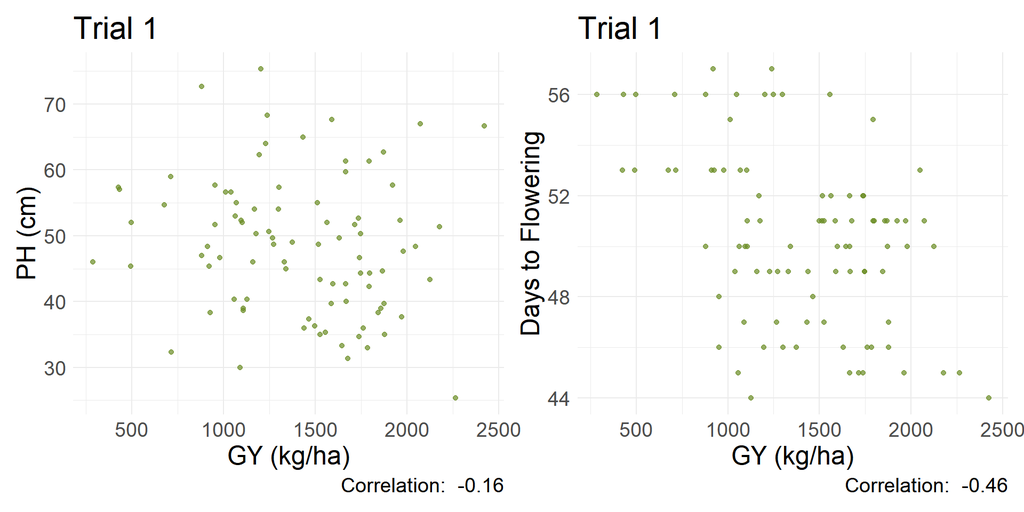

Figure 13: Trial 1 - Scatter Plots

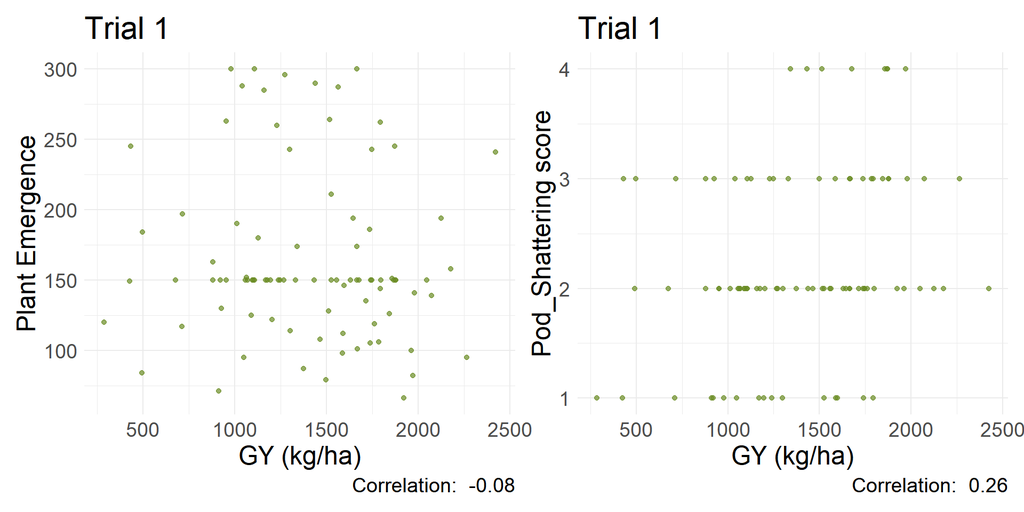

Figure 14: Trial 1 - Scatter Plots

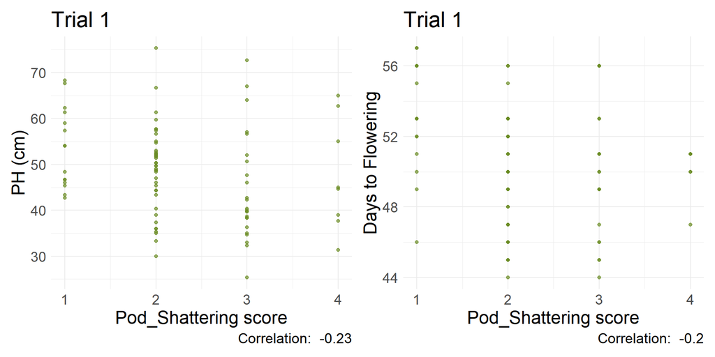

Figure 15: Trial 1 - Scatter Plots

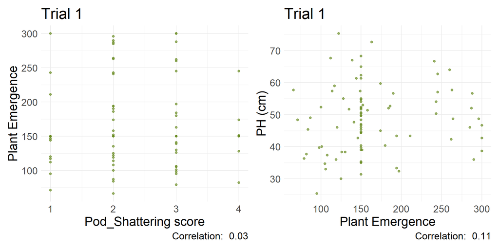

Figure 16: Trial 1 - Scatter Plots

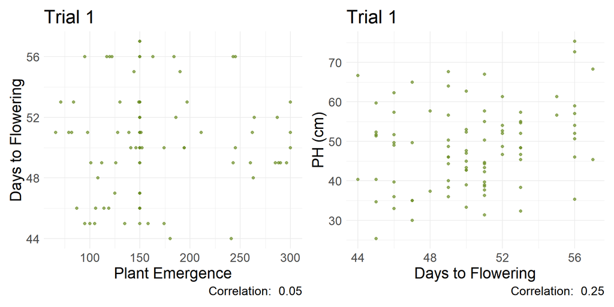

Figure 17: Trial 1 - Scatter Plots

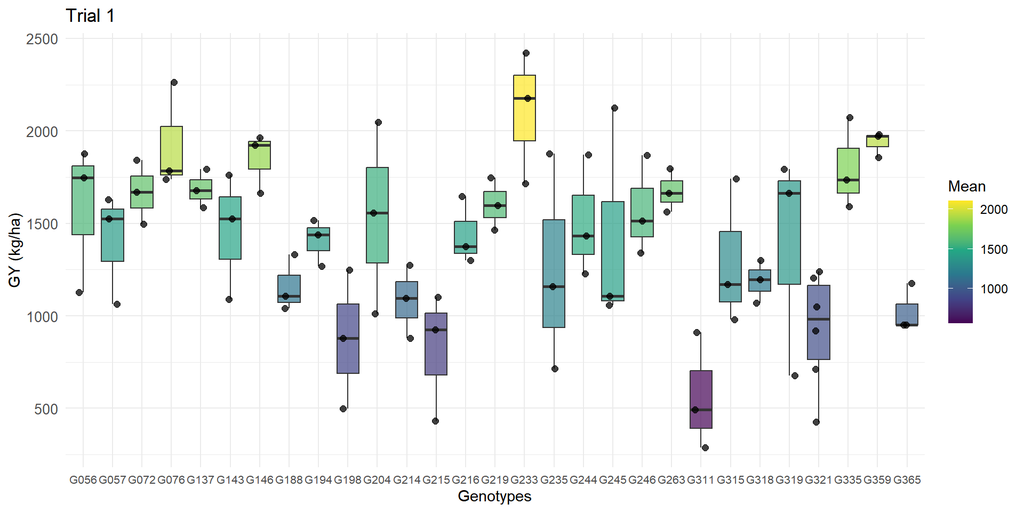

Figure 18: Trial 1 Genotypes Boxplot - Grain Yield

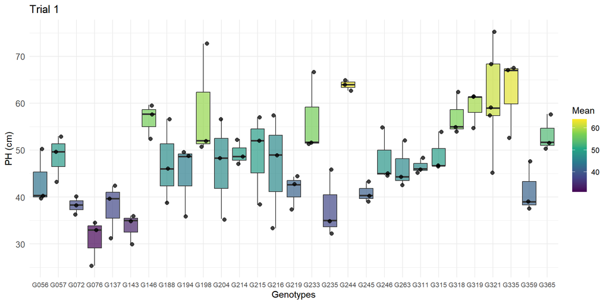

Figure 19: Trial 1 Genotypes Boxplot - Plant Height

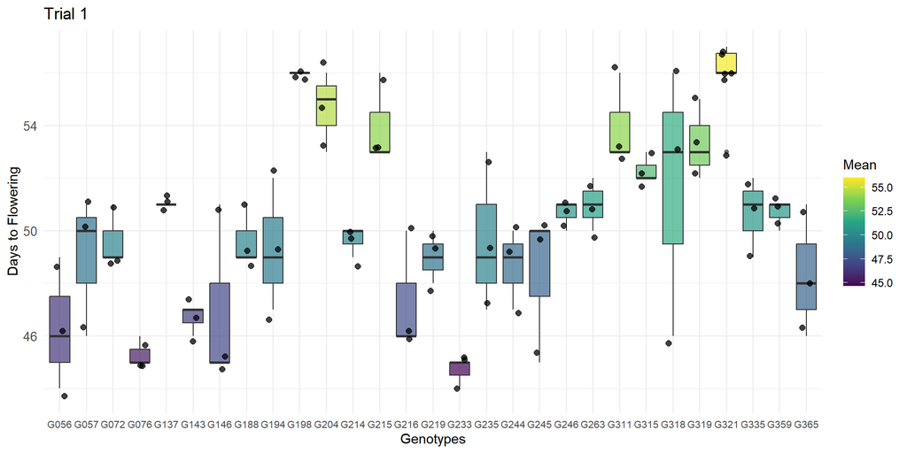

Figure 20: Trial 1 Genotypes Boxplot - Flowering Days

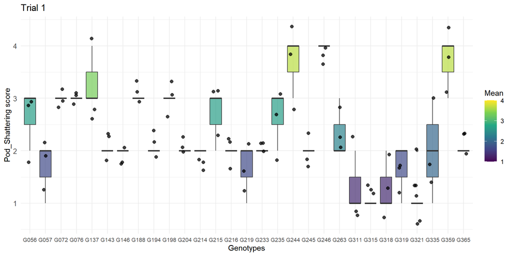

Figure 21: Trial 1 Genotypes Boxplot - Pod Shattering

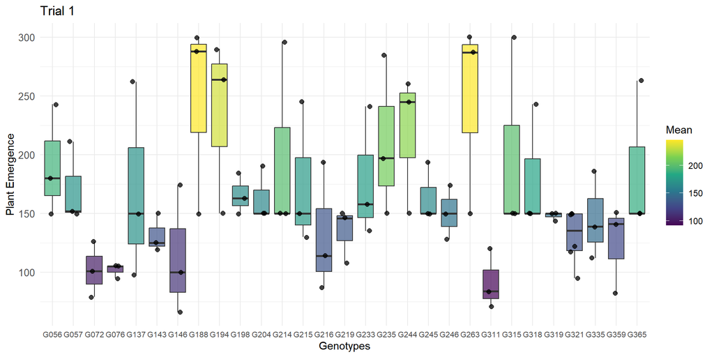

Figure 22: Trial 1 Genotypes Boxplot - Plant Emergence

# Trial 2 - Local “L0133” / Year “2023”

The Trial 2 (L0133) stands out as a high-potential environment with strong phenotypic stability for most traits. The mean GY reached 3,676 kg/ha, with a median of 3,712 kg/ha. This symmetry, achieved after the removal of previously identified outliers, indicates a balanced data distribution, allowing for a reliable assessment of genotype performance. The range (1,421 to 5,684 kg/ha) demonstrates that despite being a favorable environment, there is sufficient genetic variability to select superior materials. The density plot for GY confirms this trend, showing a well-defined curve shifted toward high-yield levels.

Regarding the crop cycle, the mean of 56.7 days to flowering (FLW_DAYS) confirms that this environment induces a longer cycle. The low standard deviation (5.64) and the narrow peak in the density plot suggest that the genotypes responded uniformly to local photoperiodic or thermal stimuli. However, PL_EMERG_COUNT showed a lot variability (9 to 219 plants) ( Figure 23). The density plot for emergence displayed a flat and wide base, visually confirming this lack of uniformity ( Figure 24).

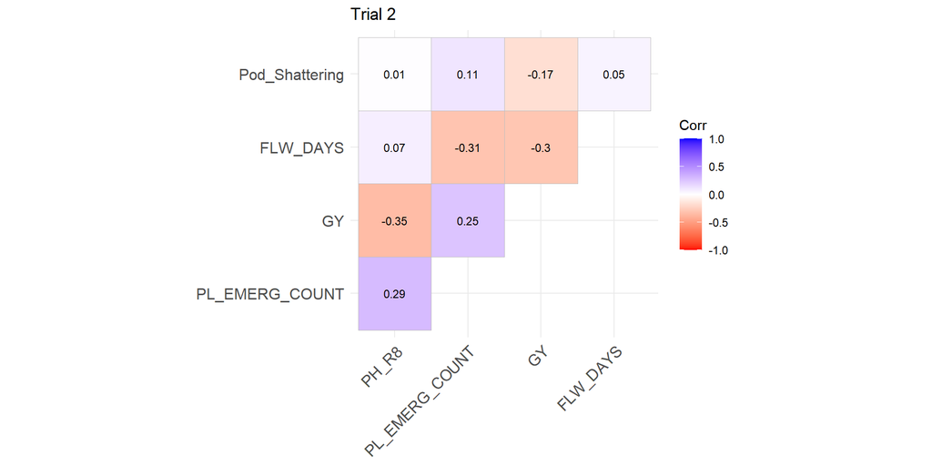

Figure 23: Trial 2 - Traits Correlation

A correlation of approximatelly -0.30 between FLW_DAYS and GY was observed when contrasted with PL_EMERG_COUNT (FLW_DAYS x PL_EMERG_COUNT; FLW_DAYS x PL_EMERG_COUNT), indicating that while the stand was irregular. Similarly, the -0.35 correlation between PH_R8 and GY suggests that taller plants were not necessarily the most productive at this site; in high-density areas, etiolation for light competition may have occurred, however, these clarification values are not very high. Finally, Pod_Shattering showed a mean of 1.07, indicating that environmental conditions exerted no selection pressure for pod dehiscence. Correlations near zero with other variables confirm that this trait remained “silent” in Trial 2. Therefore, while this site is excellent for evaluating yield potential and plant architecture, it does not provide discriminatory information for shattering resistance, as nearly all materials displayed stable behavior and minimum scores.

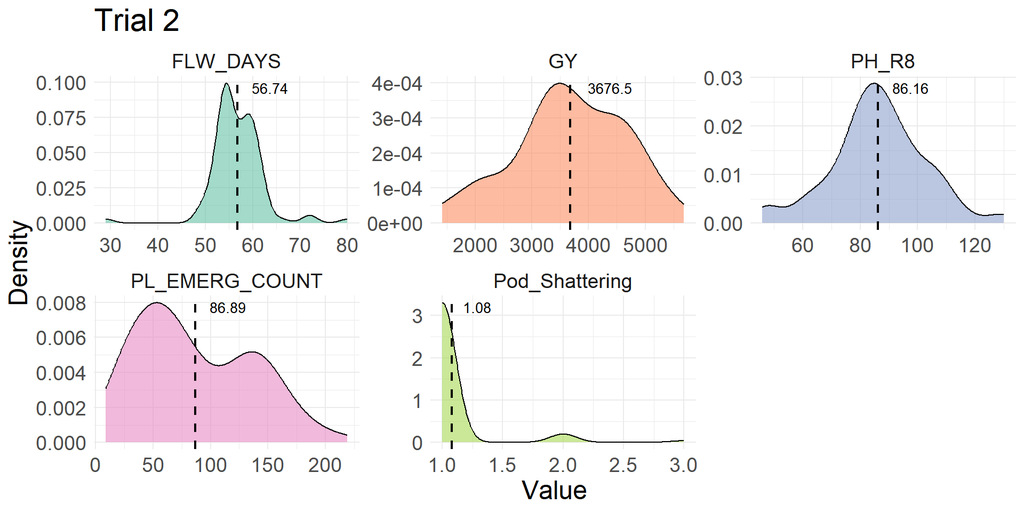

Figure 24: Trial 2 - Traits Density Plot

Regarding the boxplots comparing treatments within each genotype, it is visually evident that most flowering data, regardless of the genotype, is concentrated within a range of 50–60 days ( Figure 34), with few individuals falling outside this window. This indicates high phenotypic stability for this trait or a uniform response to the photoperiod and temperature conditions of the specific site and growing season. A similar pattern is observed for pod shattering, where observations across genotypes remained between 0.5 and 1.5 ( Figure 35), suggesting that the evaluated population possesses high mechanical resistance to pod dehiscence and low genetic variability for this in Trial 2.

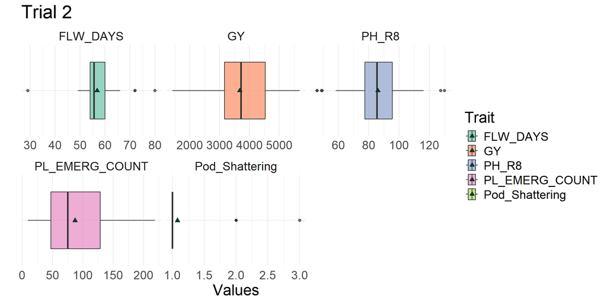

Figure 25: Trial 2 - Traits Boxplot

[figure not shown]

Figure 26: Trial 2 - Traits Histogram

The scatter plot analysis for Trial 2 clarifies the trade-offs between traits under high-potential conditions. A notable negative trend was observed between plant height and yield, where the highest-yielding genotypes were concentrated within an intermediate height range (80–100 cm). Plants exceeding 110 cm showed a significant decline in productivity, suggesting that excessive vegetative growth at this site was likely a result of etiolation due to light competition rather than high genetic vigor ( Figure 27). This indicates an inefficient energy partitioning, where the plants prioritized stem elongation over grain filling.

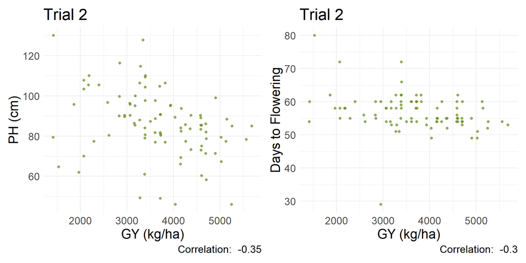

Figure 27: Trial 2 - Scatter Plots

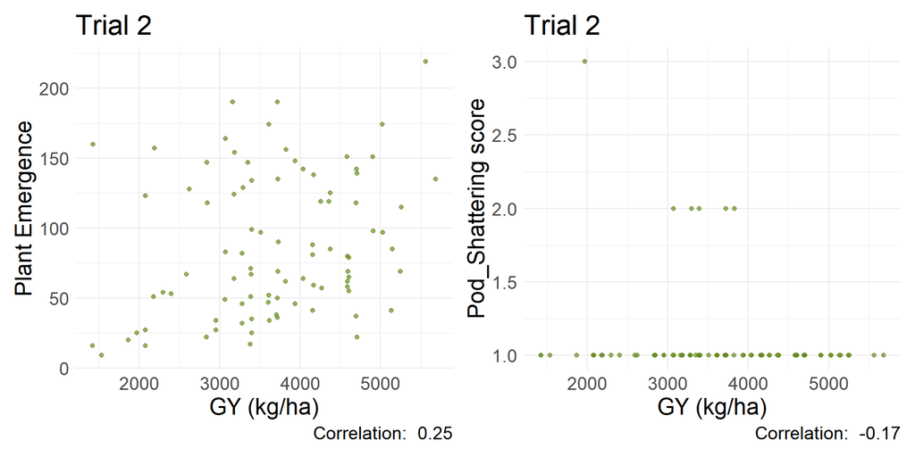

Figure 28: Trial 2 - Scatter Plots

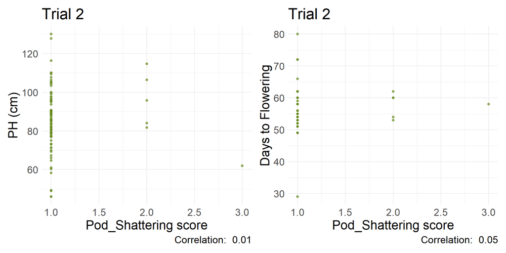

Figure 29: Trial 2 - Scatter Plots

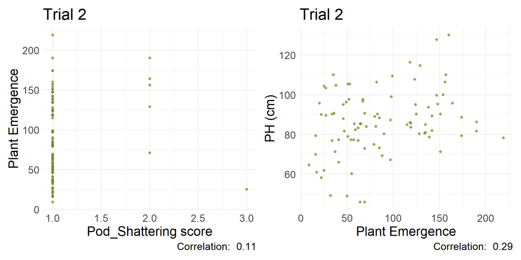

Figure 30: Trial 2 - Scatter Plots

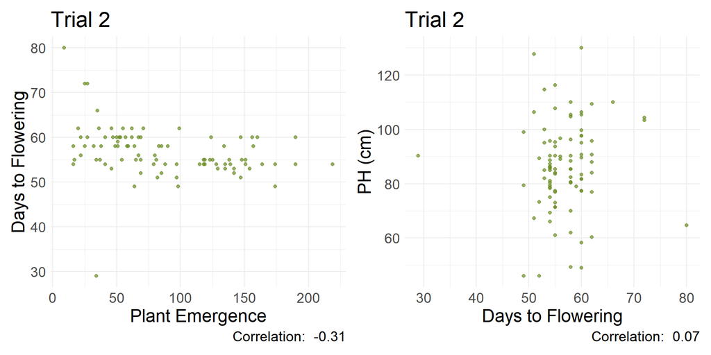

Figure 31: Trial 2 - Scatter Plots

In Trial 2, the most significant contrasts between genotypes are observed in Grain Yield (GY), Plant Height (PH), and plant emergence. Regarding GY, genotypes G072, G076, G137, G143, G194, G216, G219, G246, and G359 stood out with positive performance, while G146, G198, G315, G318, G319, and G321 showed negative highlights, with means settling near 3,000 kg/ha ( Figure 32).